# Thesis - MSc Data Science & Data Analytics

**Title:** How Do ECB Interest Rate Changes Shape Customer Behaviour and Portfolio Risk in European Banking?

**Dataset:** bank-additional-full.csv

## Imports & Setup

```python
import pandas as pd
import numpy as np
import matplotlib.pyplot as plt
import seaborn as sns
from sklearn.preprocessing import StandardScaler
from sklearn.decomposition import PCA
from sklearn.cluster import KMeans, AgglomerativeClustering
from sklearn.metrics import silhouette_score, adjusted_rand_score
from scipy.cluster.hierarchy import dendrogram, linkage
from scipy.stats import f_oneway, chi2_contingency
import warnings
warnings.filterwarnings('ignore')

plt.rcParams['figure.figsize'] = (12, 5)
plt.rcParams['axes.spines.top']   = False
plt.rcParams['axes.spines.right'] = False
print("All libraries imported successfully")
```

```
All libraries imported successfully
```

## Load Dataset

```python
# Always reload from scratch — this clears any state from previous runs
bank_data = pd.read_csv('bank-additional-full.csv', sep=';', quotechar='"', encoding='utf-8')
bank_data.rename(columns={'y': 'banking_product_adopted'}, inplace=True)

# Reset all derived variables so re-running cells never uses stale state
bank_data_clean   = None
bank_data_cluster = None
num_cols          = None

print('Dataset loaded fresh:', bank_data.shape)
print('Columns:', bank_data.columns.tolist())
bank_data.head()
```

```
Dataset loaded fresh: (41188, 21)
Columns: ['age', 'job', 'marital', 'education', 'default', 'housing', 'loan', 'contact', 'month', 'day_of_week', 'duration', 'campaign', 'pdays', 'previous', 'poutcome', 'emp.var.rate', 'cons.price.idx', 'cons.conf.idx', 'euribor3m', 'nr.employed', 'banking_product_adopted']
```

|  | age | job | marital | education | default | housing | loan | contact | month | day_of_week | ... | campaign | pdays | previous | poutcome | emp.var.rate | cons.price.idx | cons.conf.idx | euribor3m | nr.employed | banking_product_adopted |
| --- | --- | --- | --- | --- | --- | --- | --- | --- | --- | --- | --- | --- | --- | --- | --- | --- | --- | --- | --- | --- | --- |
| 0 | 56 | housemaid | married | basic.4y | no | no | no | telephone | may | mon | ... | 1 | 999 | 0 | nonexistent | 1.1 | 93.994 | -36.4 | 4.857 | 5191.0 | no |
| 1 | 57 | services | married | high.school | unknown | no | no | telephone | may | mon | ... | 1 | 999 | 0 | nonexistent | 1.1 | 93.994 | -36.4 | 4.857 | 5191.0 | no |
| 2 | 37 | services | married | high.school | no | yes | no | telephone | may | mon | ... | 1 | 999 | 0 | nonexistent | 1.1 | 93.994 | -36.4 | 4.857 | 5191.0 | no |
| 3 | 40 | admin. | married | basic.6y | no | no | no | telephone | may | mon | ... | 1 | 999 | 0 | nonexistent | 1.1 | 93.994 | -36.4 | 4.857 | 5191.0 | no |
| 4 | 56 | services | married | high.school | no | no | yes | telephone | may | mon | ... | 1 | 999 | 0 | nonexistent | 1.1 | 93.994 | -36.4 | 4.857 | 5191.0 | no |

5 rows × 21 columns

# Part A - Exploratory Data Analysis (EDA)

## EDA Step 1 -Dataset Shape and Data Types

**Why:** Confirm data loaded correctly and every column has the right data type before any analysis.

```python
print("DATASET SHAPE AND DATA TYPES")
print(f"Rows    : {bank_data.shape[0]:,}")
print(f"Columns : {bank_data.shape[1]}")
print()
print("Data types per column:")
print(bank_data.dtypes)
```

```
DATASET SHAPE AND DATA TYPES
Rows    : 41,188
Columns : 21

Data types per column:
age                          int64
job                         object
marital                     object
education                   object
default                     object
housing                     object
loan                        object
contact                     object
month                       object
day_of_week                 object
duration                     int64
campaign                     int64
pdays                        int64
previous                     int64
poutcome                    object
emp.var.rate               float64
cons.price.idx             float64
cons.conf.idx              float64
euribor3m                  float64
nr.employed                float64
banking_product_adopted     object
dtype: object
```

## EDA Step 2 - Missing Values

**Why:** Missing values break most ML models. Also check for 'unknown' entries which act as hidden missing values.

```python
print("MISSING VALUES")
missing = bank_data.isnull().sum()
print("Missing values per column:")
print(missing)
print(f"\nTotal missing values : {missing.sum()}")
print(f"Dataset is complete  : {missing.sum() == 0}")

print("\n'unknown' counts:")
cat_cols = bank_data.select_dtypes(include='object').columns
for col in cat_cols:
    count = (bank_data[col] == 'unknown').sum()
    if count > 0:
        pct = count / len(bank_data) * 100
        print(f"  {col:<22} : {count:,} ({pct:.1f}%)")
```

```
MISSING VALUES
Missing values per column:
age                        0
job                        0
marital                    0
education                  0
default                    0
housing                    0
loan                       0
contact                    0
month                      0
day_of_week                0
duration                   0
campaign                   0
pdays                      0
previous                   0
poutcome                   0
emp.var.rate               0
cons.price.idx             0
cons.conf.idx              0
euribor3m                  0
nr.employed                0
banking_product_adopted    0
dtype: int64

Total missing values : 0
Dataset is complete  : True

'unknown' counts:
  job                    : 330 (0.8%)
  marital                : 80 (0.2%)
  education              : 1,731 (4.2%)
  default                : 8,597 (20.9%)
  housing                : 990 (2.4%)
  loan                   : 990 (2.4%)
```

## EDA Step 3 - Duplicate Records

**Why:** Duplicates inflate model accuracy.

```python
print("DUPLICATE RECORDS")
dupes = bank_data.duplicated().sum()
print(f"Duplicate rows found : {dupes}")
print(f"Percentage           : {dupes/len(bank_data)*100:.2f}%")
if dupes > 0:
    bank_data.drop_duplicates(inplace=True)
    bank_data.reset_index(drop=True, inplace=True)
    print(f"Duplicates removed. New shape: {bank_data.shape}")
```

```
DUPLICATE RECORDS
Duplicate rows found : 12
Percentage           : 0.03%
Duplicates removed. New shape: (41176, 21)
```

## EDA Step 4 - Descriptive Statistics

**Why:** Understand scale, centre, and spread of every column. Reveals anomalies like pdays=999 and extreme values in duration.

```python
print('DESCRIPTIVE STATISTICS')

# Define all 10 numeric columns
num_cols = ['age', 'duration', 'campaign', 'pdays', 'previous',
            'emp.var.rate', 'cons.price.idx', 'cons.conf.idx',
            'euribor3m', 'nr.employed']

# Safety check — only keep columns that exist (handles re-runs)
num_cols = [col for col in num_cols if col in bank_data.columns]

print(f'Columns found: {len(num_cols)}')
print(f'List: {num_cols}')
print()
#print(bank_data[num_cols].describe().round(2).to_string())
print(bank_data.columns)
```

```
DESCRIPTIVE STATISTICS
Columns found: 10
List: ['age', 'duration', 'campaign', 'pdays', 'previous', 'emp.var.rate', 'cons.price.idx', 'cons.conf.idx', 'euribor3m', 'nr.employed']

Index(['age', 'job', 'marital', 'education', 'default', 'housing', 'loan',
       'contact', 'month', 'day_of_week', 'duration', 'campaign', 'pdays',
       'previous', 'poutcome', 'emp.var.rate', 'cons.price.idx',
       'cons.conf.idx', 'euribor3m', 'nr.employed', 'banking_product_adopted'],
      dtype='object')
```

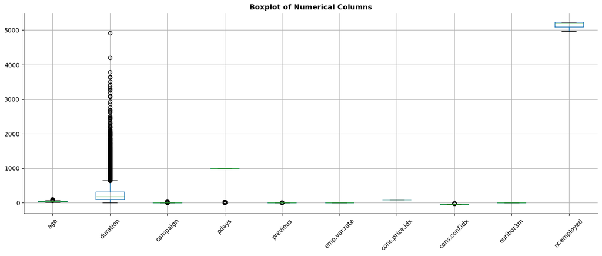

```python
# Boxplots
bank_data[num_cols].boxplot(figsize=(14, 6))
plt.xticks(rotation=45)
plt.title("Boxplot of Numerical Columns", fontweight='bold')
plt.tight_layout()
plt.show()
```

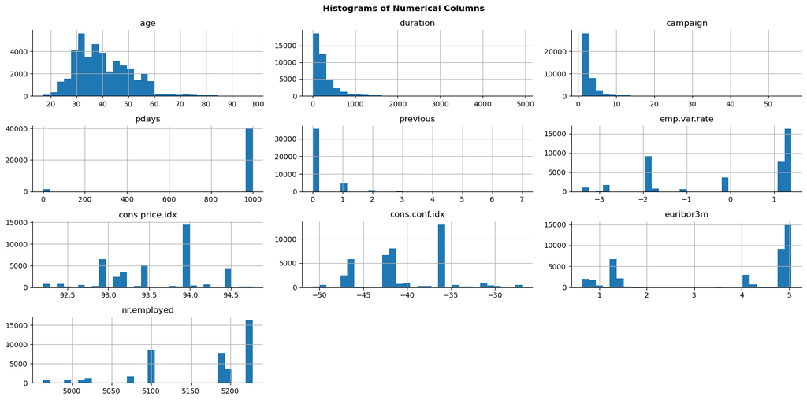

```python
# Histograms
bank_data[num_cols].hist(bins=30, figsize=(16, 8))
plt.suptitle("Histograms of Numerical Columns", fontweight='bold')
plt.tight_layout()
plt.show()
```

## EDA Step 5 - Skewness Analysis

**Why:** Models like K-Means and regression assume roughly normal distributions. Heavily skewed variables need transformation.

```python
print("SKEWNESS ANALYSIS")
skewness = bank_data[num_cols].skew().round(3)
for col, skew in skewness.items():
    flag = "SKEWED -- needs fix" if abs(skew) > 1 else "OK"
    print(f"  {col:<22} : {skew:>7.3f}  {flag}")
```

```
SKEWNESS ANALYSIS
  age                    :   0.785  OK
  duration               :   3.263  SKEWED -- needs fix
  campaign               :   4.762  SKEWED -- needs fix
  pdays                  :  -4.921  SKEWED -- needs fix
  previous               :   3.831  SKEWED -- needs fix
  emp.var.rate           :  -0.724  OK
  cons.price.idx         :  -0.231  OK
  cons.conf.idx          :   0.303  OK
  euribor3m              :  -0.709  OK
  nr.employed            :  -1.044  SKEWED -- needs fix
```

[figure not shown]

```python
# Skewness bar chart
skewness.plot(kind='bar', color='#2E75B6', alpha=0.8, figsize=(12, 5))
plt.title("Skewness of Numerical Columns", fontweight='bold')
plt.axhline( 1, color='red', linestyle='--', label='+1 threshold')
plt.axhline(-1, color='red', linestyle='--', label='-1 threshold')
plt.xticks(rotation=45)
plt.legend()
plt.tight_layout()
plt.show()
```

```python
# Apply log1p to highly skewed columns
high_skew = skewness[abs(skewness) > 1]
print("Applying log1p transformation:")
for col in high_skew.index:
    bank_data[col + '_log'] = np.log1p(bank_data[col])
    print(f"  {col}: before={bank_data[col].skew():.3f}  after={bank_data[col + '_log'].skew():.3f}")
```

```
Applying log1p transformation:
  duration: before=3.263  after=-0.421
  campaign: before=4.762  after=1.350
  pdays: before=-4.921  after=-5.005
  previous: before=3.831  after=2.587
  nr.employed: before=-1.044  after=-1.064
```

I applied log1p transformation to reduce skewness in highly skewed variables. Log transformation compresses large values and helps make the distribution more symmetric. Log transformation did not improve pdays because it contains a special value (999), which represents a categorical condition rather than a true numeric value.

## EDA Step 6 - Outlier Detection (IQR Method)

**Why:** Outliers distort means and pull K-Means cluster centroids away from the true data centre.

```python
print("OUTLIER DETECTION (IQR METHOD)")
for col in num_cols:
    Q1    = bank_data[col].quantile(0.25)
    Q3    = bank_data[col].quantile(0.75)
    IQR   = Q3 - Q1
    mask  = (bank_data[col] < Q1 - 1.5*IQR) | (bank_data[col] > Q3 + 1.5*IQR)
    count = mask.sum()
    pct   = count / len(bank_data) * 100
    flag  = "ACTION NEEDED" if pct > 3 else ""
    print(f"  {col:<22}: {count:>5,} outliers ({pct:.1f}%)  {flag}")
```

```
OUTLIER DETECTION (IQR METHOD)
  age                   :   468 outliers (1.1%)
  duration              : 2,963 outliers (7.2%)  ACTION NEEDED
  campaign              : 2,406 outliers (5.8%)  ACTION NEEDED
  pdays                 : 1,515 outliers (3.7%)  ACTION NEEDED
  previous              : 5,625 outliers (13.7%)  ACTION NEEDED
  emp.var.rate          :     0 outliers (0.0%)
  cons.price.idx        :     0 outliers (0.0%)
  cons.conf.idx         :   446 outliers (1.1%)
  euribor3m             :     0 outliers (0.0%)
  nr.employed           :     0 outliers (0.0%)
```

```
Capping outliers (At 95th percentile):
  campaign: max before=56  |  capped at=7
  previous: max before=7  |  capped at=1
```

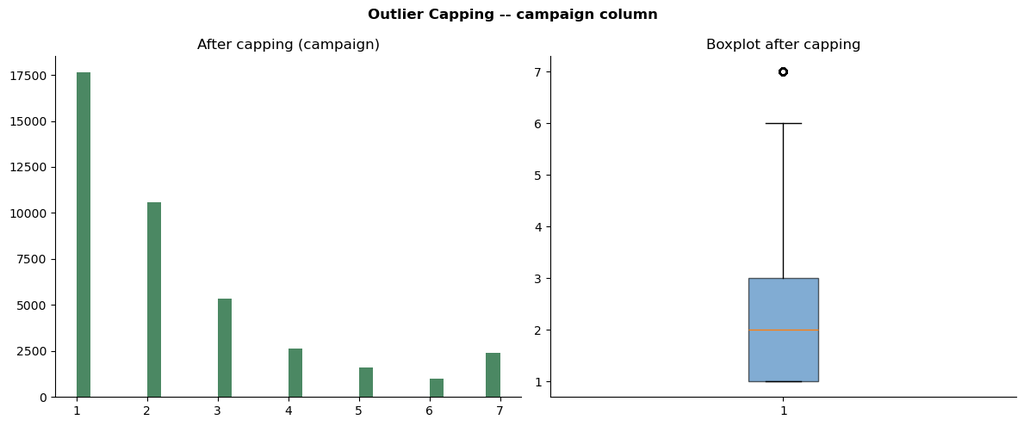

```python
# Cap outliers at 95th percentile
print("Capping outliers (At 95th percentile):")
for col in ['campaign', 'previous']:
    cap    = bank_data[col].quantile(0.95)
    before = bank_data[col].max()
    bank_data[col] = bank_data[col].clip(upper=cap)
    print(f"  {col}: max before={before:.0f}  |  capped at={cap:.0f}")

fig, (ax1, ax2) = plt.subplots(1, 2, figsize=(12, 5))
fig.suptitle("Outlier Capping -- campaign column", fontweight='bold')
ax1.hist(bank_data['campaign'], bins=30, color='#1E6B3C', alpha=0.8)
ax1.set_title("After capping (campaign)")
ax2.boxplot(bank_data['campaign'], patch_artist=True,
            boxprops=dict(facecolor='#2E75B6', alpha=0.6))
ax2.set_title("Boxplot after capping")
plt.tight_layout()
plt.show()
```

I used the Interquartile Range (IQR) method to detect outliers. It identifies values that lie far outside the typical range of the data. Outlier detection is important because extreme values can distort statistical analysis and negatively impact machine learning models, especially those sensitive to scale like regression. I used capping instead of removing outliers to avoid losing data, especially since these values may contain important information.

## EDA Step 7 - Class Balance Analysis

**Why:** 88.7% no vs 11.3% yes (7.9:1 ratio). A model predicting 'no' for every customer scores 88.7% accuracy but is completely useless — it never finds a single subscriber.

**Approach chosen — Class Weight / scale_pos_weight:**

Rather than synthetically generating new data points, we handle the imbalance directly inside the model by **penalising misclassification of the minority class more heavily**.

- For **XGBoost**: `scale_pos_weight = 7.9` — tells the model that missing a subscriber costs 7.9× more than missing a non-subscriber
- For **Logistic Regression / SVM** (if used): `class_weight='balanced'` — automatically adjusts weights inversely proportional to class frequency

```python
print("CLASS BALANCE ANALYSIS")
counts = bank_data['banking_product_adopted'].value_counts()
pcts   = bank_data['banking_product_adopted'].value_counts(normalize=True) * 100
ratio  = counts['no'] / counts['yes']
print(f"no  : {counts['no']:,}  ({pcts['no']:.1f}%)")
print(f"yes : {counts['yes']:,}  ({pcts['yes']:.1f}%)")
print(f"Imbalance ratio : {ratio:.1f}:1")
print()

# Class weight calculation — used instead of SMOTE
class_weight_yes = round(counts['no'] / counts['yes'], 2)
class_weight_no  = 1.0
print("Imbalance handling: Class Weighting (not SMOTE)")
print(f"  scale_pos_weight for XGBoost   : {class_weight_yes}")
print(f"  class_weight for sklearn models: 'balanced' (auto-computed)")
print(f"Applied in XGBoost: scale_pos_weight = {class_weight_yes}")
```

```
CLASS BALANCE ANALYSIS
no  : 36,537  (88.7%)
yes : 4,639  (11.3%)
Imbalance ratio : 7.9:1

Imbalance handling: Class Weighting (not SMOTE)
  scale_pos_weight for XGBoost   : 7.88
  class_weight for sklearn models: 'balanced' (auto-computed)
Applied in XGBoost: scale_pos_weight = 7.88
```

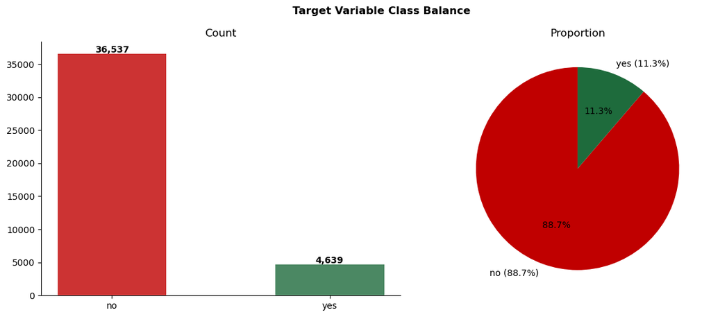

```python
fig, (ax1, ax2) = plt.subplots(1, 2, figsize=(12, 5))
fig.suptitle("Target Variable Class Balance", fontweight='bold')
ax1.bar(['no', 'yes'], counts.values, color=['#C00000', '#1E6B3C'], alpha=0.8, width=0.5)
ax1.set_title("Count")
for i, (cat, val) in enumerate(counts.items()):
    ax1.text(i, val + 200, f'{val:,}', ha='center', fontweight='bold')
ax2.pie(counts.values, labels=['no (88.7%)', 'yes (11.3%)'],
        colors=['#C00000', '#1E6B3C'], autopct='%1.1f%%', startangle=90)
ax2.set_title("Proportion")
plt.tight_layout()
plt.show()

bank_data['target'] = (bank_data['banking_product_adopted'] == 'yes').astype(int)
```

## EDA Step 7b - Class Weight Visualisation

**Why:** Shows how class weighting corrects the effective learning signal seen by the model — making the minority class (subscribers) carry equal weight in training despite being underrepresented in the raw data.

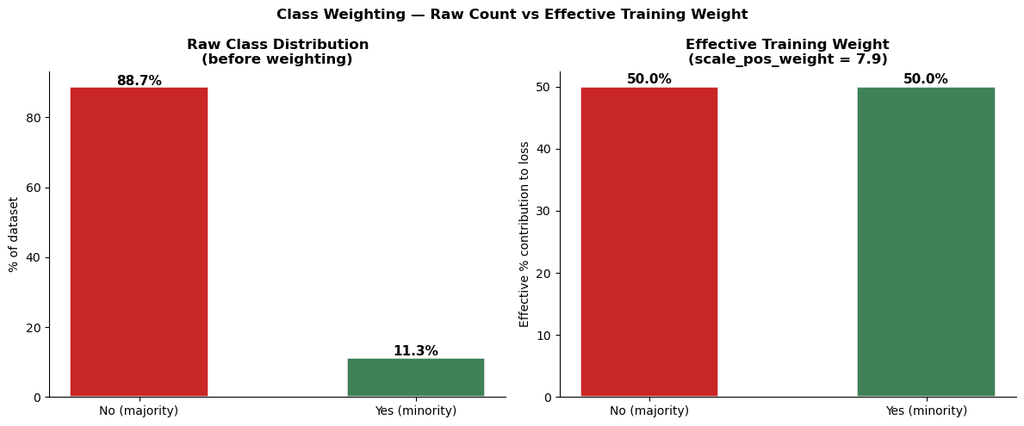

```
Class weighting summary:
  Raw 'no'  count : 36,537  weight: 1.0  effective: 36,537
  Raw 'yes' count : 4,639  weight: 7.9  effective: 36,537
  After weighting both classes contribute equally to model training
```

```python
# Visualise effective weight after class weighting
labels   = ['No (majority)', 'Yes (minority)']
raw_pcts = [counts['no'] / len(bank_data) * 100,
            counts['yes'] / len(bank_data) * 100]

# After class weighting: effective contribution = count × weight
weight_no  = 1.0
weight_yes = counts['no'] / counts['yes']
eff_no  = counts['no']  * weight_no
eff_yes = counts['yes'] * weight_yes
total_eff   = eff_no + eff_yes
eff_pcts = [eff_no/total_eff*100, eff_yes/total_eff*100]

fig, axes = plt.subplots(1, 2, figsize=(12, 5))
fig.suptitle("Class Weighting — Raw Count vs Effective Training Weight",
             fontweight='bold')

colors = ['#C00000', '#1E6B3C']
x = np.arange(2)
w = 0.35

axes[0].bar(x, raw_pcts, color=colors, alpha=0.85, width=0.5, edgecolor='white', linewidth=1.2)
axes[0].set_title('Raw Class Distribution\n(before weighting)', fontweight='bold')
axes[0].set_xticks(x)
axes[0].set_xticklabels(labels)
axes[0].set_ylabel('% of dataset')
for i, v in enumerate(raw_pcts):
    axes[0].text(i, v+0.5, f'{v:.1f}%', ha='center', fontweight='bold', fontsize=11)

axes[1].bar(x, eff_pcts, color=colors, alpha=0.85, width=0.5, edgecolor='white', linewidth=1.2)
axes[1].set_title(f'Effective Training Weight\n(scale_pos_weight = {weight_yes:.1f})',
                  fontweight='bold')
axes[1].set_xticks(x)
axes[1].set_xticklabels(labels)
axes[1].set_ylabel('Effective % contribution to loss')
for i, v in enumerate(eff_pcts):
    axes[1].text(i, v+0.5, f'{v:.1f}%', ha='center', fontweight='bold', fontsize=11)

plt.tight_layout()
plt.show()

print("Class weighting summary:")
print(f"  Raw 'no'  count : {counts['no']:,}  weight: {weight_no:.1f}  effective: {eff_no:,.0f}")
print(f"  Raw 'yes' count : {counts['yes']:,}  weight: {weight_yes:.1f}  effective: {eff_yes:,.0f}")
print(f"  After weighting both classes contribute equally to model training")
```

Class balance analysis checks whether the target variable is evenly distributed across classes. In my dataset, the target variable is imbalanced, meaning one class dominates the other. The dataset is highly imbalanced, with the majority class ‘no’ being almost 8 times larger than the minority class ‘yes’. If not handled, the model will become biased toward the majority class and may predict ‘no’ most of the time, ignoring the minority class. Handling class imbalance is important because the goal is not just accuracy, but correctly identifying the minority class, which is often more important in real-world scenarios.

I used class weighting instead of SMOTE to avoid generating synthetic data and to maintain the original data distribution. After applying class weights, both classes contribute equally to the model training despite the imbalance in raw data. Class weighting increases the penalty for misclassifying the minority class, forcing the model to pay more attention to it. I chose not to use SMOTE because it creates synthetic samples, which can introduce noise and lead to overfitting. Since my dataset is large enough, class weighting is a simpler and more robust approach. The dataset was highly imbalanced with a ratio of 7.9:1. To address this, I used class weighting instead of resampling techniques like SMOTE. In XGBoost, I applied scale_pos_weight to give higher importance to the minority class. This ensures that both classes contribute equally during training and prevents the model from being biased toward the majority class.

## EDA Step 8 - Correlation Analysis

**Why:** Identifies which features predict the target AND detects multicollinearity. euribor3m vs emp.var.rate r=0.97 - critical for VAR model in Component 2.

```python
print("CORRELATION ANALYSIS")
corr_cols   = num_cols + ['target']
corr_matrix = bank_data[corr_cols].corr().round(3)
target_corr = corr_matrix['target'].drop('target').sort_values()
print("Correlation with target:")
for col, val in target_corr.items():
    sign = '+' if val > 0 else '-'
    bar  = '#' * int(abs(val) * 30)
    print(f"  {col:<22}: {val:>7.3f}  {sign}{bar}")
```

```
CORRELATION ANALYSIS
Correlation with target:
  nr.employed           :  -0.355  -##########
  pdays                 :  -0.325  -#########
  euribor3m             :  -0.308  -#########
  emp.var.rate          :  -0.298  -########
  cons.price.idx        :  -0.136  -####
  campaign              :  -0.070  -##
  age                   :   0.030  +
  cons.conf.idx         :   0.055  +#
  previous              :   0.194  +#####
  duration              :   0.405  +############
```

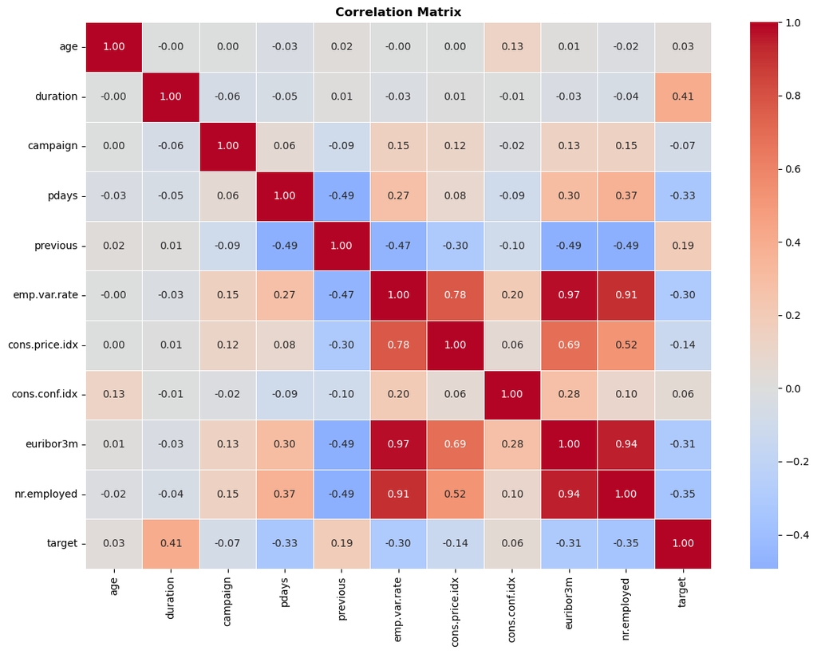

```python
# Heatmap
plt.figure(figsize=(12, 9))
sns.heatmap(corr_matrix, annot=True, fmt='.2f', cmap='coolwarm',
            center=0, linewidths=0.5, annot_kws={'size': 10})
plt.title("Correlation Matrix", fontweight='bold')
plt.tight_layout()
plt.show()
```

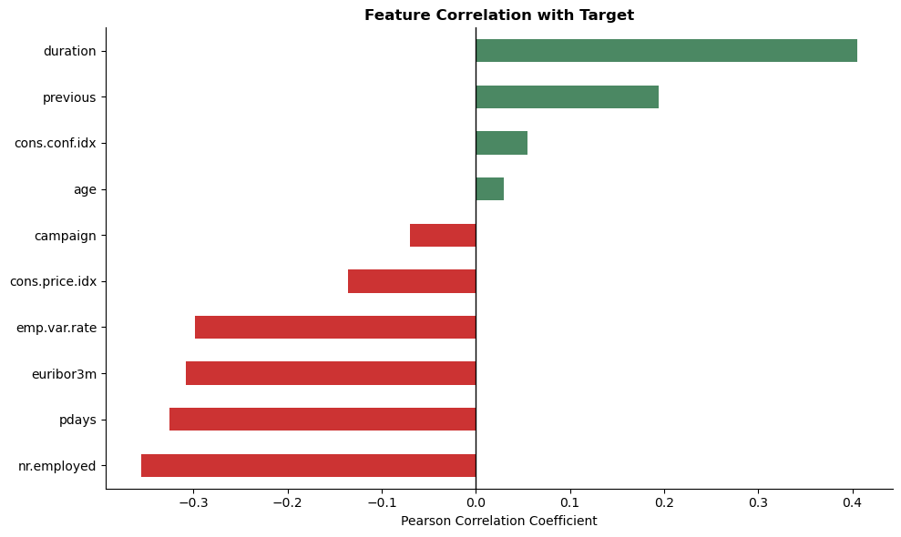

```python
# Target correlation bar
cols_bar = ['#C00000' if v < 0 else '#1E6B3C' for v in target_corr.values]
target_corr.plot(kind='barh', color=cols_bar, alpha=0.8, figsize=(10, 6))
plt.title("Feature Correlation with Target", fontweight='bold')
plt.xlabel("Pearson Correlation Coefficient")
plt.axvline(0, color='black', linewidth=1)
plt.tight_layout()
plt.show()
```

I performed correlation analysis to understand the relationship between independent variables and the target variable. I found that duration has the strongest positive correlation, while economic indicators such as euribor3m and nr.employed show strong negative correlation. However, correlation only captures linear relationships, so even weakly correlated variables may still be useful in machine learning models. Correlation analysis is useful for initial feature understanding, but final feature selection should be based on model performance and feature importance.

## EDA Step 9 - Feature vs Target Comparison

**Why:** Turns correlation numbers into a human story. Directly answers 'what is different about customers who subscribed?'

```python
print("FEATURE vs TARGET COMPARISON")
comparison = bank_data.groupby('banking_product_adopted')[num_cols].mean().round(3)
diff       = comparison.loc['yes'] - comparison.loc['no']
print(f"{'Feature':<22} {'Subscribed':>14} {'Not Subscribed':>16} {'Difference':>12}")
print("-" * 68)
for col in num_cols:
    print(f"  {col:<22} {comparison.loc['yes',col]:>14.3f}"
          f" {comparison.loc['no',col]:>16.3f}"
          f" {diff[col]:>12.3f}")
```

```
FEATURE vs TARGET COMPARISON
Feature                    Subscribed   Not Subscribed   Difference
--------------------------------------------------------------------
  age                            40.912           39.911        1.001
  duration                      553.256          220.868      332.388
  campaign                        1.997            2.377       -0.380
  pdays                         791.991          984.109     -192.118
  previous                        0.323            0.113        0.210
  emp.var.rate                   -1.233            0.249       -1.482
  cons.price.idx                 93.355           93.604       -0.249
  cons.conf.idx                 -39.791          -40.593        0.802
  euribor3m                       2.123            3.811       -1.688
  nr.employed                  5095.120         5176.166      -81.046
```

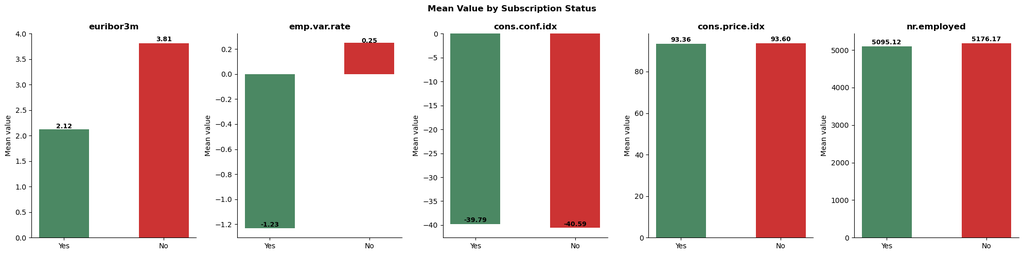

```python
macro_cols = ['euribor3m', 'emp.var.rate', 'cons.conf.idx', 'cons.price.idx', 'nr.employed']
fig, axes = plt.subplots(1, 5, figsize=(20, 5))
fig.suptitle("Mean Value by Subscription Status", fontweight='bold')
for i, col in enumerate(macro_cols):
    vals = [comparison.loc['yes', col], comparison.loc['no', col]]
    axes[i].bar(['Yes', 'No'], vals, color=['#1E6B3C', '#C00000'], alpha=0.8, width=0.5)
    axes[i].set_title(col, fontweight='bold')
    axes[i].set_ylabel("Mean value")
    for j, v in enumerate(vals):
        axes[i].text(j, v * 1.01 if v > 0 else v * 0.99,
                     f'{v:.2f}', ha='center', fontsize=9, fontweight='bold')
plt.tight_layout()
plt.show()
```

## EDA Step 10 - Categorical Feature Analysis

**Why:** poutcome=success gives 65.1% subscription -> strongest predictor. month varies 8x. day_of_week varies less than 2% -> safe to drop.

```python
print("CATEGORICAL FEATURE ANALYSIS")
cat_features = ['job', 'marital', 'education', 'contact',
                'month', 'poutcome', 'housing', 'loan']
for col in cat_features:
    rates  = bank_data.groupby(col)['target'].mean().sort_values(ascending=False)
    counts_col = bank_data[col].value_counts()
    print(f"\n{col.upper()}:")
    print(f"  {'Category':<25} {'Sub Rate':>10} {'Count':>8}")
    print("  " + "-"*45)
    for cat in rates.index:
        print(f"  {cat:<25} {rates[cat]:>9.1%} {counts_col[cat]:>8,}")
```

```
CATEGORICAL FEATURE ANALYSIS

JOB:
  Category                    Sub Rate    Count
  ---------------------------------------------
  student                       31.4%      875
  retired                       25.3%    1,718
  unemployed                    14.2%    1,014
  admin.                        13.0%   10,419
  management                    11.2%    2,924
  unknown                       11.2%      330
  technician                    10.8%    6,739
  self-employed                 10.5%    1,421
  housemaid                     10.0%    1,060
  entrepreneur                   8.5%    1,456
  services                       8.1%    3,967
  blue-collar                    6.9%    9,253

MARITAL:
  Category                    Sub Rate    Count
  ---------------------------------------------
  unknown                       15.0%       80
  single                        14.0%   11,564
  divorced                      10.3%    4,611
  married                       10.2%   24,921

EDUCATION:
  Category                    Sub Rate    Count
  ---------------------------------------------
  illiterate                    22.2%       18
  unknown                       14.5%    1,730
  university.degree             13.7%   12,164
  professional.course           11.4%    5,240
  high.school                   10.8%    9,512
  basic.4y                      10.2%    4,176
  basic.6y                       8.2%    2,291
  basic.9y                       7.8%    6,045

CONTACT:
  Category                    Sub Rate    Count
```

[output cut: 23 more lines]

```
  nonexistent                    8.8%   35,551

HOUSING:
  Category                    Sub Rate    Count
  ---------------------------------------------
  yes                           11.6%   21,571
  no                            10.9%   18,615
  unknown                       10.8%      990

LOAN:
  Category                    Sub Rate    Count
  ---------------------------------------------
  no                            11.3%   33,938
  yes                           10.9%    6,248
  unknown                       10.8%      990
```

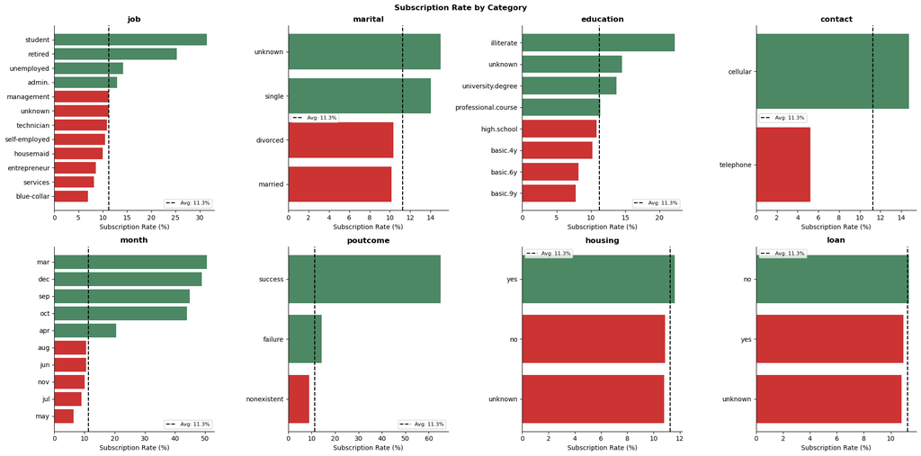

```python
fig, axes = plt.subplots(2, 4, figsize=(20, 10))
fig.suptitle("Subscription Rate by Category", fontweight='bold')
avg = bank_data['target'].mean()
for i, col in enumerate(cat_features):
    ax    = axes[i // 4][i % 4]
    rates = bank_data.groupby(col)['target'].mean().sort_values()
    cols  = ['#1E6B3C' if v > avg else '#C00000' for v in rates.values]
    ax.barh(rates.index, rates.values * 100, color=cols, alpha=0.8)
    ax.axvline(avg * 100, color='black', linestyle='--', linewidth=1.5,
               label=f'Avg: {avg:.1%}')
    ax.set_title(col, fontweight='bold')
    ax.set_xlabel("Subscription Rate (%)")
    ax.legend(fontsize=8)
plt.tight_layout()
plt.show()
```

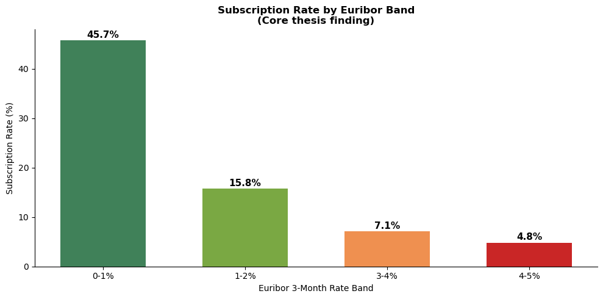

```python
# Euribor bands - core thesis finding
bank_data['euribor_band'] = pd.cut(
    bank_data['euribor3m'],
    bins=[0, 1, 2, 3, 4, 5.1],
    labels=['0-1%', '1-2%', '2-3%', '3-4%', '4-5%'])
euribor_rates = bank_data.groupby('euribor_band', observed=True)['target'].mean() * 100

fig, ax = plt.subplots(figsize=(10, 5))
b_colors = ['#1E6B3C', '#639922', '#ED7D31', '#C00000', '#C00000']
bars = ax.bar(euribor_rates.index, euribor_rates.values, color=b_colors, alpha=0.85, width=0.6)
ax.set_title("Subscription Rate by Euribor Band\n(Core thesis finding)", fontweight='bold')
ax.set_xlabel("Euribor 3-Month Rate Band")
ax.set_ylabel("Subscription Rate (%)")
for bar, val in zip(bars, euribor_rates.values):
    ax.text(bar.get_x() + bar.get_width() / 2,
            val + 0.5, f'{val:.1f}%', ha='center', fontweight='bold', fontsize=11)
plt.tight_layout()
plt.savefig('step10_euribor_bands.png', dpi=150, bbox_inches='tight')
plt.show()
```

## EDA Step 11 - Multicollinearity Check (VIF)

**Why:** euribor3m and emp.var.rate have r=0.97. Including both in a VAR model makes coefficients untrustworthy.

```python
print("MULTICOLLINEARITY CHECK (VIF)")
macro_cols_vif = ['emp.var.rate', 'cons.price.idx', 'cons.conf.idx', 'euribor3m', 'nr.employed']
macro_corr     = bank_data[macro_cols_vif].corr().round(3)
print("Correlation matrix:")
print(macro_corr.to_string())
print("\nPairs with r > 0.7:")
for i in range(len(macro_cols_vif)):
    for j in range(i + 1, len(macro_cols_vif)):
        r    = macro_corr.iloc[i, j]
        if abs(r) > 0.7:
            flag = "CRITICAL" if abs(r) > 0.9 else "HIGH"
            print(f"  {macro_cols_vif[i]:<20} vs {macro_cols_vif[j]:<20}: r={r:.3f}  [{flag}]")
```

```
MULTICOLLINEARITY CHECK (VIF)
Correlation matrix:
                emp.var.rate  cons.price.idx  cons.conf.idx  euribor3m  nr.employed
emp.var.rate           1.000           0.775          0.196      0.972        0.907
cons.price.idx         0.775           1.000          0.059      0.688        0.522
cons.conf.idx          0.196           0.059          1.000      0.278        0.101
euribor3m              0.972           0.688          0.278      1.000        0.945
nr.employed            0.907           0.522          0.101      0.945        1.000

Pairs with r > 0.7:
  emp.var.rate         vs cons.price.idx      : r=0.775  [HIGH]
  emp.var.rate         vs euribor3m           : r=0.972  [CRITICAL]
  emp.var.rate         vs nr.employed         : r=0.907  [CRITICAL]
  euribor3m            vs nr.employed         : r=0.945  [CRITICAL]
```

```python
try:
    from statsmodels.stats.outliers_influence import variance_inflation_factor
    from statsmodels.tools.tools import add_constant
    X_vif = add_constant(bank_data[macro_cols_vif].dropna())
    vif_df = pd.DataFrame({
        'Feature': macro_cols_vif,
        'VIF': [variance_inflation_factor(X_vif.values, i + 1) for i in range(len(macro_cols_vif))]
    }).sort_values('VIF', ascending=False)
    print("VIF Scores (>5=concern, >10=critical):")
    for _, row in vif_df.iterrows():
        flag = "CRITICAL" if row['VIF'] > 10 else "CONCERN" if row['VIF'] > 5 else "OK"
        print(f"  {row['Feature']:<22}: VIF = {row['VIF']:>8.2f}  [{flag}]")
except ImportError:
    print("Install statsmodels: pip install statsmodels")
```

```
VIF Scores (>5=concern, >10=critical):
  euribor3m             : VIF =    63.86  [CRITICAL]
  emp.var.rate          : VIF =    32.90  [CRITICAL]
  nr.employed           : VIF =    30.74  [CRITICAL]
  cons.price.idx        : VIF =     6.29  [CONCERN]
  cons.conf.idx         : VIF =     2.60  [OK]
```

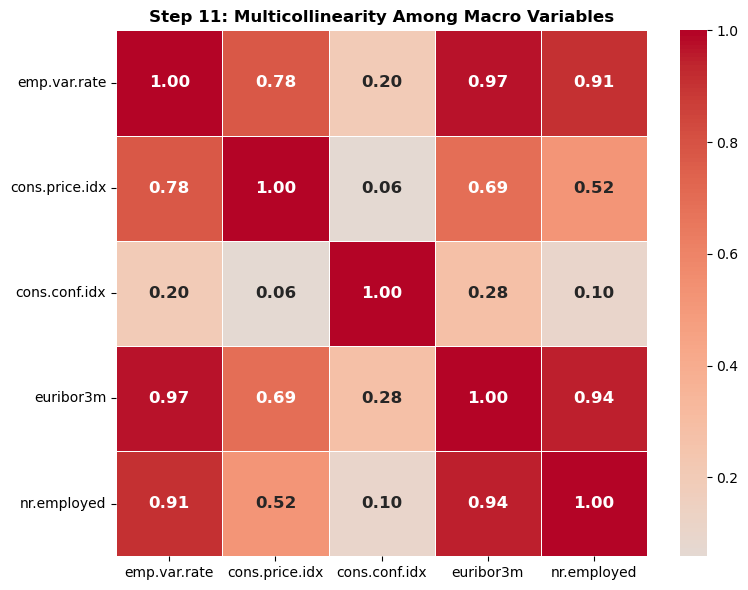

```python
plt.figure(figsize=(8, 6))
sns.heatmap(macro_corr, annot=True, fmt='.2f', cmap='coolwarm', center=0,
            linewidths=0.5, annot_kws={'size': 12, 'weight': 'bold'})
plt.title("Step 11: Multicollinearity Among Macro Variables", fontweight='bold')
plt.tight_layout()
plt.show()
```

## EDA Step 12 - Preprocessing: Apply All Decisions

**Why:** Applies every decision from Steps 1-11 in one controlled pass. Produces the clean dataset ready for Components 2 and 3.

```python
print("PREPROCESSING")
bank_data_clean = bank_data.copy()

bank_data_clean.drop(columns=['duration', 'day_of_week'], inplace=True)
print("[1] Dropped: duration (leakage), day_of_week (no signal)")

bank_data_clean['default'] = bank_data_clean['default'].map(
    {'no': 0, 'yes': 1, 'unknown': 1}).fillna(0).astype(int)
print("[2] default recoded as binary")

bank_data_clean['pdays_flag'] = (bank_data_clean['pdays'] < 999).astype(int)
bank_data_clean.drop(columns=['pdays'], inplace=True)
print("[3] pdays recoded as pdays_flag")

bank_data_clean['banking_product_adopted'] = (
    bank_data_clean['banking_product_adopted'] == 'yes').astype(int)
print("[4] Target encoded: yes=1, no=0")

cat_encode = ['job', 'marital', 'education', 'contact', 'month', 'poutcome', 'housing', 'loan']
bank_data_clean = pd.get_dummies(bank_data_clean, columns=cat_encode, drop_first=True)
print(f"[5] One-hot encoded {len(cat_encode)} categorical columns")

drop_helpers = ['euribor_band', 'target', 'campaign_log', 'previous_log',
                'pdays_log', 'duration_log', 'nr.employed_log']
bank_data_clean.drop(columns=[c for c in drop_helpers if c in bank_data_clean.columns], inplace=True)
print("[6] Dropped analysis-only helper columns")

scale_cols = [c for c in ['age', 'campaign', 'previous', 'emp.var.rate',
              'cons.price.idx', 'cons.conf.idx', 'euribor3m', 'nr.employed']
              if c in bank_data_clean.columns]
bank_data_clean[scale_cols] = StandardScaler().fit_transform(bank_data_clean[scale_cols])
print(f"[7] StandardScaler applied to {len(scale_cols)} columns")

print(f"\nFinal shape : {bank_data_clean.shape}")
bank_data_clean.to_csv('bank_marketing_cleaned.csv', index=False)
print("Saved: bank_marketing_cleaned.csv")
```

```
PREPROCESSING
[1] Dropped: duration (leakage), day_of_week (no signal)
[2] default recoded as binary
[3] pdays recoded as pdays_flag
[4] Target encoded: yes=1, no=0
[5] One-hot encoded 8 categorical columns
[6] Dropped analysis-only helper columns
[7] StandardScaler applied to 8 columns

Final shape : (41176, 48)
Saved: bank_marketing_cleaned.csv
```

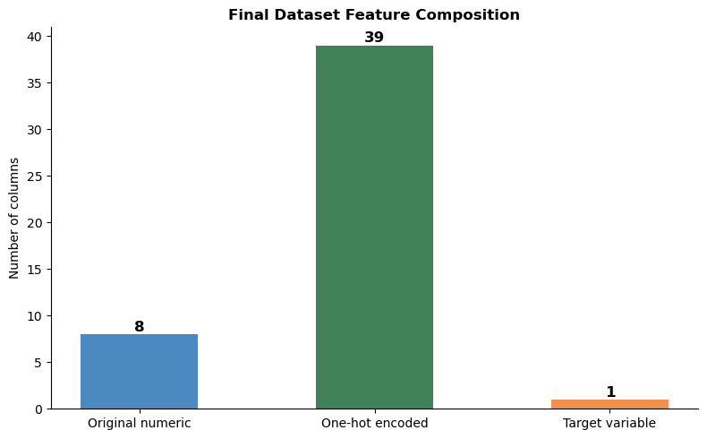

```python
feature_types = {
    'Original numeric': len(scale_cols),
    'One-hot encoded': bank_data_clean.shape[1] - len(scale_cols) - 1,
    'Target variable': 1
}
plt.figure(figsize=(8, 5))
plt.bar(feature_types.keys(), feature_types.values(),
        color=['#2E75B6', '#1E6B3C', '#ED7D31'], alpha=0.85, width=0.5)
plt.title("Final Dataset Feature Composition", fontweight='bold')
plt.ylabel("Number of columns")
for i, (k, v) in enumerate(feature_types.items()):
    plt.text(i, v + 0.3, str(v), ha='center', fontweight='bold', fontsize=12)
plt.tight_layout()
plt.show()
```

# Part B: Customer Segmentation

**RQ1:** How do bank customers cluster into distinct financial behaviour profiles, and how do these profiles differ in their exposure to interest rate risk?

**Methods:** K-Means vs Hierarchical Clustering (Ward Linkage)

## RQ 1 - Step 1: Preprocessing for Clustering

**Why:** Clustering needs ordinal encoding (not one-hot) so distance calculations work correctly. We use a fresh copy of bank_data.

```python
print("PREPROCESSING FOR CLUSTERING")
bank_data_cluster = bank_data.copy()

bank_data_cluster.drop(columns=['duration', 'day_of_week'], errors='ignore', inplace=True)
bank_data_cluster['pdays_flag'] = (bank_data_cluster['pdays'] < 999).astype(int)
bank_data_cluster.drop(columns=['pdays'], inplace=True)
bank_data_cluster['default'] = bank_data_cluster['default'].map({'no': 0, 'yes': 1, 'unknown': 1})
bank_data_cluster['target']  = (bank_data_cluster['banking_product_adopted'] == 'yes').astype(int)

edu_map = {'illiterate':0,'basic.4y':1,'basic.6y':2,'basic.9y':3,
           'high.school':4,'professional.course':5,'university.degree':6,'unknown':3}
job_map = {'student':0,'unemployed':1,'housemaid':2,'services':3,'blue-collar':4,
           'technician':5,'self-employed':6,'entrepreneur':7,'management':8,'admin.':9,
           'retired':10,'unknown':5}

bank_data_cluster['education_ord'] = bank_data_cluster['education'].map(edu_map)
bank_data_cluster['job_ord']       = bank_data_cluster['job'].map(job_map)
bank_data_cluster['marital_ord']   = bank_data_cluster['marital'].map({'single':0,'divorced':1,'married':2,'unknown':1})
bank_data_cluster['housing_ord']   = bank_data_cluster['housing'].map({'no':0,'unknown':0,'yes':1})
bank_data_cluster['loan_ord']      = bank_data_cluster['loan'].map({'no':0,'unknown':0,'yes':1})
bank_data_cluster['poutcome_ord']  = bank_data_cluster['poutcome'].map({'nonexistent':0,'failure':1,'success':2})

cluster_features = ['age','job_ord','marital_ord','education_ord','housing_ord','loan_ord',
                    'campaign','previous','pdays_flag','poutcome_ord',
                    'emp.var.rate','cons.price.idx','cons.conf.idx','euribor3m','nr.employed']

X = bank_data_cluster[cluster_features].copy()
for col in ['campaign', 'previous']:
    X[col] = np.log1p(X[col].clip(upper=X[col].quantile(0.95)))

X_scaled = StandardScaler().fit_transform(X).astype(np.float32)
print(f"Clustering features : {len(cluster_features)}")
print(f"Scaled matrix shape : {X_scaled.shape}")
```

```
PREPROCESSING FOR CLUSTERING
Clustering features : 15
Scaled matrix shape : (41176, 15)
```

## Step 2: PCA

**Why:** Compress 15 features into 2 dimensions for visualisation and noise removal.

```
PCA
Components for 80% variance : 8
Components for 90% variance : 9
2 components explain        : 40.7%
```

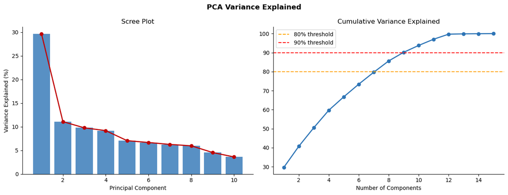

```python
print("PCA")
pca_full = PCA(random_state=42)
pca_full.fit(X_scaled)
cum_var  = np.cumsum(pca_full.explained_variance_ratio_)

pca2  = PCA(n_components=2, random_state=42)
X_pca = pca2.fit_transform(X_scaled)

print(f"Components for 80% variance : {np.argmax(cum_var >= 0.80) + 1}")
print(f"Components for 90% variance : {np.argmax(cum_var >= 0.90) + 1}")
print(f"2 components explain        : {pca2.explained_variance_ratio_.sum()*100:.1f}%")

fig, (ax1, ax2) = plt.subplots(1, 2, figsize=(13, 5))
fig.suptitle("PCA Variance Explained", fontweight='bold', fontsize=13)
ax1.bar(range(1, 11), pca_full.explained_variance_ratio_[:10] * 100, color='#2E75B6', alpha=0.8)
ax1.plot(range(1, 11), pca_full.explained_variance_ratio_[:10] * 100, 'o-', color='#C00000', linewidth=2)
ax1.set_title("Scree Plot")
ax1.set_xlabel("Principal Component")
ax1.set_ylabel("Variance Explained (%)")
ax2.plot(range(1, len(cum_var)+1), cum_var * 100, 'o-', color='#2E75B6', linewidth=2)
ax2.axhline(80, color='orange', linestyle='--', label='80% threshold')
ax2.axhline(90, color='red',    linestyle='--', label='90% threshold')
ax2.set_title("Cumulative Variance Explained")
ax2.set_xlabel("Number of Components")
ax2.legend()
plt.tight_layout()
plt.show()
```

## Step 3: Elbow Method + Silhouette Score

**Why:** K-Means needs you to choose K before running. These two methods help identify the best K objectively.

```
ELBOW + SILHOUETTE
```

[output not shown]

```
  K=2  WCSS=     459,889  Silhouette=0.2933
  K=3  WCSS=     397,815  Silhouette=0.2786
  K=4  WCSS=     359,577  Silhouette=0.2961
  K=5  WCSS=     331,380  Silhouette=0.1657
  K=6  WCSS=     330,685  Silhouette=0.1473

  Best K = 4  Silhouette = 0.2961
```

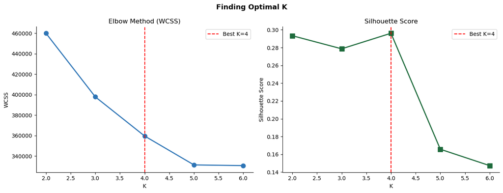

```python
print("ELBOW + SILHOUETTE")
wcss, sil_km = [], []
for k in range(2, 7):
    km     = KMeans(n_clusters=k, random_state=42, n_init=5, max_iter=200)
    labels = km.fit_predict(X_scaled)
    wcss.append(km.inertia_)
    s = silhouette_score(X_scaled, labels, sample_size=3000, random_state=42)
    sil_km.append(s)
    print(f"  K={k}  WCSS={km.inertia_:>12,.0f}  Silhouette={s:.4f}")

best_k_km = range(2, 7)[sil_km.index(max(sil_km))]
print(f"\n  Best K = {best_k_km}  Silhouette = {max(sil_km):.4f}")

fig, (ax1, ax2) = plt.subplots(1, 2, figsize=(13, 5))
fig.suptitle("Finding Optimal K", fontweight='bold', fontsize=13)
ax1.plot(range(2,7), wcss, 'o-', color='#2E75B6', linewidth=2, markersize=8)
ax1.axvline(best_k_km, color='red', linestyle='--', label=f'Best K={best_k_km}')
ax1.set_title("Elbow Method (WCSS)")
ax1.set_xlabel("K")
ax1.set_ylabel("WCSS")
ax1.legend()
ax2.plot(range(2,7), sil_km, 's-', color='#1E6B3C', linewidth=2, markersize=8)
ax2.axvline(best_k_km, color='red', linestyle='--', label=f'Best K={best_k_km}')
ax2.set_title("Silhouette Score")
ax2.set_xlabel("K")
ax2.set_ylabel("Silhouette Score")
ax2.legend()
plt.tight_layout()
plt.show()
```

## K-Means Clustering

**Why:** Groups customers by minimising the total distance from each customer to its cluster centre.

```python
print("K-MEANS CLUSTERING")
km_final  = KMeans(n_clusters=best_k_km, random_state=42, n_init=10)
km_labels = km_final.fit_predict(X_scaled)
bank_data_cluster['kmeans_cluster'] = km_labels
km_sil = silhouette_score(X_scaled, km_labels, sample_size=3000, random_state=42)
print(f"K-Means k={best_k_km}  Silhouette = {km_sil:.4f}")
print("\nCluster sizes:")
for c in sorted(bank_data_cluster['kmeans_cluster'].unique()):
    n = (bank_data_cluster['kmeans_cluster'] == c).sum()
    print(f"  Cluster {c}: {n:,} customers ({n/len(bank_data_cluster)*100:.1f}%)")
```

```
K-MEANS CLUSTERING
K-Means k=4  Silhouette = 0.2961

Cluster sizes:
  Cluster 0: 26,939 customers (65.4%)
  Cluster 1: 4,110 customers (10.0%)
  Cluster 2: 1,515 customers (3.7%)
  Cluster 3: 8,612 customers (20.9%)
```

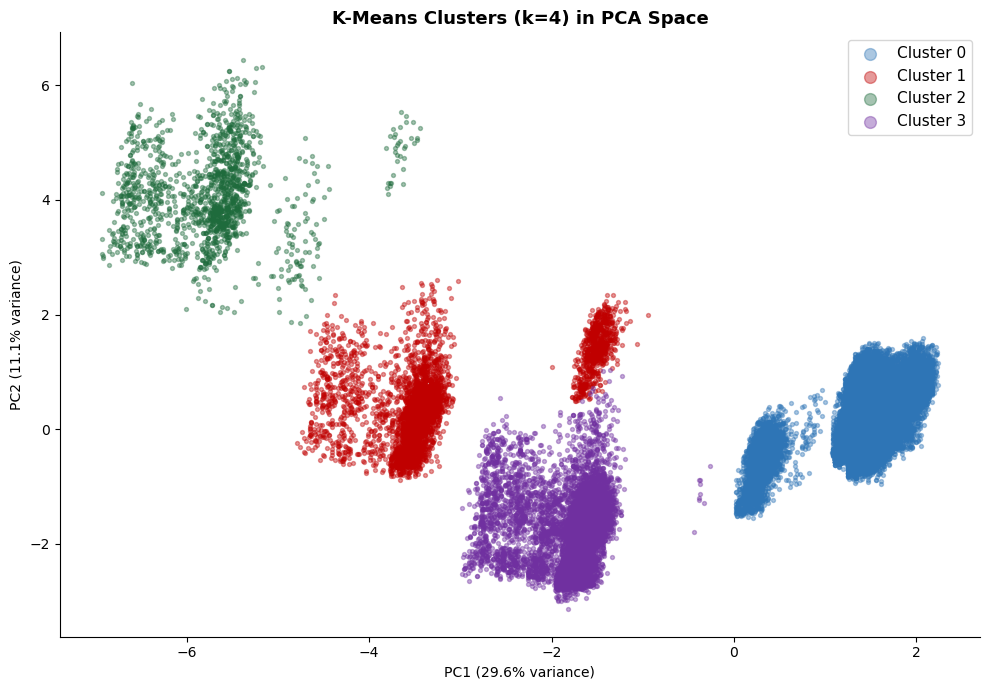

```python
colors = ['#2E75B6', '#C00000', '#1E6B3C', '#7030A0', '#ED7D31']
fig, ax = plt.subplots(figsize=(10, 7))
for c in sorted(bank_data_cluster['kmeans_cluster'].unique()):
    mask = km_labels == c
    ax.scatter(X_pca[mask, 0], X_pca[mask, 1], c=colors[c], label=f'Cluster {c}', alpha=0.4, s=8)
ax.set_title(f"K-Means Clusters (k={best_k_km}) in PCA Space", fontweight='bold', fontsize=13)
ax.set_xlabel(f"PC1 ({pca2.explained_variance_ratio_[0]*100:.1f}% variance)")
ax.set_ylabel(f"PC2 ({pca2.explained_variance_ratio_[1]*100:.1f}% variance)")
ax.legend(markerscale=3, fontsize=11)
plt.tight_layout()
plt.show()
```

## Step 5: Hierarchical Clustering (Ward)

**Why:** Validates K-Means. If both methods find similar groups, the clusters are real and stable.

```
HIERARCHICAL CLUSTERING
```

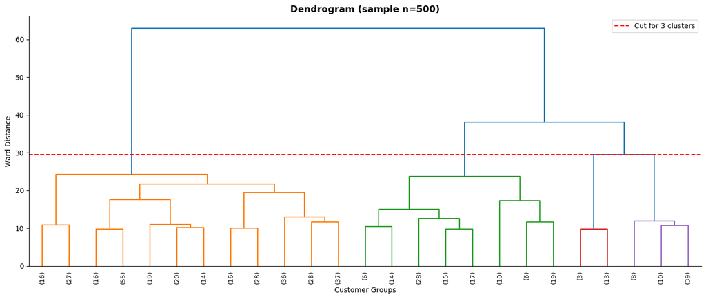

```python
print("HIERARCHICAL CLUSTERING")
sample_idx = np.random.RandomState(42).choice(len(X_scaled), 500, replace=False)
Z = linkage(X_scaled[sample_idx], method='ward')

fig, ax = plt.subplots(figsize=(14, 6))
dendrogram(Z, truncate_mode='lastp', p=25, leaf_rotation=90, leaf_font_size=9, ax=ax,
           color_threshold=Z[-3, 2])
ax.set_title("Dendrogram (sample n=500)", fontweight='bold', fontsize=13)
ax.set_xlabel("Customer Groups")
ax.set_ylabel("Ward Distance")
ax.axhline(y=Z[-3, 2], color='red', linestyle='--', label='Cut for 3 clusters')
ax.legend()
plt.tight_layout()
plt.show()
```

```python
print("HC Silhouette scores (sample n=5000):")
samp_idx2 = np.random.RandomState(42).choice(len(X_scaled), 5000, replace=False)
X_samp    = X_scaled[samp_idx2]
sil_hc    = []
for k in range(2, 7):
    hc     = AgglomerativeClustering(n_clusters=k, linkage='ward')
    labels = hc.fit_predict(X_samp)
    s      = silhouette_score(X_samp, labels, random_state=42)
    sil_hc.append(s)
    print(f"  K={k}  Silhouette = {s:.4f}")

best_k_hc = range(2, 7)[sil_hc.index(max(sil_hc))]
print(f"\n  Best HC K = {best_k_hc}")

hc_final  = AgglomerativeClustering(n_clusters=best_k_hc, linkage='ward')
hc_labels = hc_final.fit_predict(X_scaled)
hc_sil    = silhouette_score(X_scaled, hc_labels, sample_size=3000, random_state=42)
bank_data_cluster['hc_cluster'] = hc_labels
print(f"  HC Silhouette (full data) = {hc_sil:.4f}")
```

```
HC Silhouette scores (sample n=5000):
  K=2  Silhouette = 0.2954
  K=3  Silhouette = 0.2993
  K=4  Silhouette = 0.2998
  K=5  Silhouette = 0.2149
  K=6  Silhouette = 0.2250

  Best HC K = 4
  HC Silhouette (full data) = 0.2962
```

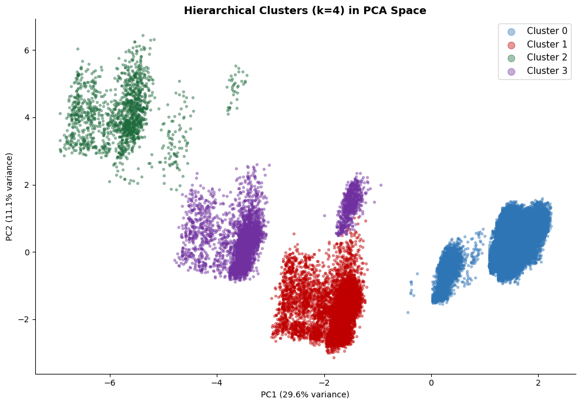

```python
fig, ax = plt.subplots(figsize=(10, 7))
for c in sorted(np.unique(hc_labels)):
    mask = hc_labels == c
    ax.scatter(X_pca[mask, 0], X_pca[mask, 1], c=colors[c], label=f'Cluster {c}', alpha=0.4, s=8)
ax.set_title(f"Hierarchical Clusters (k={best_k_hc}) in PCA Space", fontweight='bold', fontsize=13)
ax.set_xlabel(f"PC1 ({pca2.explained_variance_ratio_[0]*100:.1f}% variance)")
ax.set_ylabel(f"PC2 ({pca2.explained_variance_ratio_[1]*100:.1f}% variance)")
ax.legend(markerscale=3, fontsize=11)
plt.tight_layout()
plt.show()
```

## Step 6: Model Comparison

**Why:** Your supervisor asked to try both methods and pick the best one. Silhouette Score is the primary metric. ARI measures how much they agree.

```
MODEL COMPARISON

Method                    Best K   Silhouette
---------------------------------------------
K-Means                        4       0.2961
Hierarchical Ward              4       0.2962

Adjusted Rand Index : 0.9992
Selected model      : Hierarchical (k=4)
```

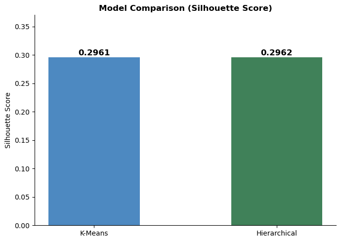

```python
print("MODEL COMPARISON")
ari = adjusted_rand_score(km_labels, hc_labels)
print(f"\n{'Method':<25} {'Best K':>6} {'Silhouette':>12}")
print("-" * 45)
print(f"{'K-Means':<25} {best_k_km:>6} {km_sil:>12.4f}")
print(f"{'Hierarchical Ward':<25} {best_k_hc:>6} {hc_sil:>12.4f}")
print(f"\nAdjusted Rand Index : {ari:.4f}")

winner      = "K-Means" if km_sil >= hc_sil else "Hierarchical"
best_k      = best_k_km if winner == "K-Means" else best_k_hc
best_labels = km_labels  if winner == "K-Means" else hc_labels
print(f"Selected model      : {winner} (k={best_k})")

fig, ax = plt.subplots(figsize=(7, 5))
bars = ax.bar(['K-Means', 'Hierarchical'], [km_sil, hc_sil],
              color=['#2E75B6', '#1E6B3C'], alpha=0.85, width=0.5)
ax.set_title("Model Comparison (Silhouette Score)", fontweight='bold')
ax.set_ylabel("Silhouette Score")
ax.set_ylim(0, max(km_sil, hc_sil) * 1.25)
for bar, val in zip(bars, [km_sil, hc_sil]):
    ax.text(bar.get_x() + bar.get_width()/2, val + 0.003,
            f'{val:.4f}', ha='center', fontweight='bold', fontsize=12)
plt.tight_layout()
plt.show()
```

## Step 7: Cluster Profiles & Segment Naming

**Why:** Gives each cluster a meaningful banking label so results are interpretable.

```python
print("C1 STEP 7: CLUSTER PROFILES")
bank_data_cluster['best_cluster'] = best_labels

print(f"\nCluster profiles:")
print(f"{'':8} {'N':>7} {'%':>5} {'Age':>5} {'Euribor':>8} {'EmpVar':>7} {'SubRate':>8} {'PrevCont':>9}")
print("-" * 60)
for c in sorted(bank_data_cluster['best_cluster'].unique()):
    g = bank_data_cluster[bank_data_cluster['best_cluster'] == c]
    n = len(g)
    print(f"  Clust {c}  {n:>7,} {n/len(bank_data_cluster)*100:>5.1f}"
          f" {g['age'].mean():>5.1f} {g['euribor3m'].mean():>8.3f}"
          f" {g['emp.var.rate'].mean():>7.3f} {g['target'].mean()*100:>7.1f}%"
          f" {g['pdays_flag'].mean()*100:>8.1f}%")

segment_names = {
    0: "High-Rate Non-Adopters",
    1: "Low-Rate Moderate Adopters",
    2: "Loyal Previously-Contacted",
    3: "Mid-Rate Low Converters"
}
bank_data_cluster['segment_name'] = bank_data_cluster['best_cluster'].map(segment_names)
print("\nSegment names:")
for k, v in segment_names.items():
    n   = (bank_data_cluster['best_cluster'] == k).sum()
    sub = bank_data_cluster[bank_data_cluster['best_cluster'] == k]['target'].mean() * 100
    print(f"  Cluster {k} -> '{v}'  (n={n:,}, sub rate={sub:.1f}%)")
```

```
C1 STEP 7: CLUSTER PROFILES

Cluster profiles:
               N     %   Age  Euribor  EmpVar  SubRate  PrevCont
------------------------------------------------------------
  Clust 0   26,948  65.4  40.2    4.836   1.149     4.9%      0.0%
  Clust 1    8,603  20.9  39.3    1.208  -2.040    21.2%      0.0%
  Clust 2    1,515   3.7  41.9    0.986  -2.096    63.8%    100.0%
  Clust 3    4,110  10.0  39.9    1.678  -1.670    12.9%      0.0%

Segment names:
  Cluster 0 -> 'High-Rate Non-Adopters'  (n=26,948, sub rate=4.9%)
  Cluster 1 -> 'Low-Rate Moderate Adopters'  (n=8,603, sub rate=21.2%)
  Cluster 2 -> 'Loyal Previously-Contacted'  (n=1,515, sub rate=63.8%)
  Cluster 3 -> 'Mid-Rate Low Converters'  (n=4,110, sub rate=12.9%)
```

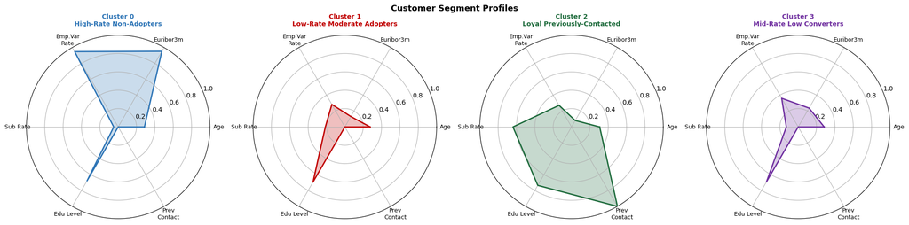

```python
categories = ['Age', 'Euribor3m', 'Emp.Var\nRate', 'Sub Rate', 'Edu Level', 'Prev\nContact']
N      = len(categories)
angles = [n / float(N) * 2 * np.pi for n in range(N)] + [0]

fig, axes = plt.subplots(1, best_k, figsize=(5*best_k, 5), subplot_kw=dict(polar=True))
fig.suptitle("Customer Segment Profiles", fontweight='bold', fontsize=13)

for i, c in enumerate(sorted(bank_data_cluster['best_cluster'].unique())):
    g    = bank_data_cluster[bank_data_cluster['best_cluster'] == c]
    vals = [
        (g['age'].mean() - 17) / (98 - 17),
        (g['euribor3m'].mean() - 0.63) / (5.05 - 0.63),
        (g['emp.var.rate'].mean() + 3.4) / (1.4 + 3.4),
        g['target'].mean(),
        g['education_ord'].mean() / 6,
        g['pdays_flag'].mean()
    ] + [0]
    vals[-1] = vals[0]
    ax = axes[i] if best_k > 1 else axes
    ax.plot(angles, vals, color=colors[c], linewidth=2)
    ax.fill(angles, vals, color=colors[c], alpha=0.25)
    ax.set_xticks(angles[:-1])
    ax.set_xticklabels(categories, size=9)
    ax.set_title(f"Cluster {c}\n{segment_names.get(c,'')}",
                 color=colors[c], fontweight='bold', size=10, pad=15)
    ax.set_ylim(0, 1)
plt.tight_layout()
plt.show()
```

## Step 8: Statistical Validation (ANOVA + Chi-Square)

**Why:** Proves the clusters are statistically meaningful, not random noise. Required for academic rigour.

```python
print("C1 STEP 8: STATISTICAL VALIDATION")
print("\nANOVA (p < 0.05 = clusters differ significantly):")
print(f"{'Feature':<22} {'F-statistic':>14} {'p-value':>12} {'Result':>10}")
print("-" * 62)
for col in ['age', 'euribor3m', 'emp.var.rate', 'cons.conf.idx', 'nr.employed']:
    groups    = [bank_data_cluster[bank_data_cluster['best_cluster'] == c][col].values
                 for c in sorted(bank_data_cluster['best_cluster'].unique())]
    f_stat, p = f_oneway(*groups)
    sig = "YES ***" if p < 0.001 else "YES *" if p < 0.05 else "NO"
    print(f"  {col:<22} {f_stat:>14.2f} {p:>12.4f} {sig:>10}")

print("\nChi-Square (subscription rate across clusters):")
ct                   = pd.crosstab(bank_data_cluster['best_cluster'],
                                   bank_data_cluster['banking_product_adopted'])
chi2_val, p_chi, dof, _ = chi2_contingency(ct)
print(f"  Chi2={chi2_val:.4f}  p-value={p_chi:.6f}  df={dof}")
print(f"  Result: {'Significant' if p_chi < 0.05 else 'Not significant'}")

print("\nSubscription rate per cluster:")
for c in sorted(bank_data_cluster['best_cluster'].unique()):
    sub = bank_data_cluster[bank_data_cluster['best_cluster'] == c]['target'].mean() * 100
    print(f"  Cluster {c} ({segment_names.get(c,'')}): {sub:.1f}%")
```

```
C1 STEP 8: STATISTICAL VALIDATION

ANOVA (p < 0.05 = clusters differ significantly):
Feature                   F-statistic      p-value     Result
--------------------------------------------------------------
  age                             32.00       0.0000    YES ***
  euribor3m                   200096.88       0.0000    YES ***
  emp.var.rate                 98755.26       0.0000    YES ***
  cons.conf.idx                 2313.40       0.0000    YES ***
  nr.employed                  61707.79       0.0000    YES ***

Chi-Square (subscription rate across clusters):
  Chi2=6159.2353  p-value=0.000000  df=3
  Result: Significant

Subscription rate per cluster:
  Cluster 0 (High-Rate Non-Adopters): 4.9%
  Cluster 1 (Low-Rate Moderate Adopters): 21.2%
  Cluster 2 (Loyal Previously-Contacted): 63.8%
  Cluster 3 (Mid-Rate Low Converters): 12.9%
```

## Step 9: Interest Rate Risk Exposure Per Segment

**This is the direct answer to RQ1.** Shows how each customer segment responds differently to ECB rate changes.

```python
print("C1 STEP 9: RATE RISK EXPOSURE -- ANSWER TO RQ1")
print()
print(f"{'Segment':<32} {'Avg Euribor':>12} {'Low Rate Sub':>14} {'High Rate Sub':>15} {'Sensitivity':>13}")
print("-" * 90)
for c in sorted(bank_data_cluster['best_cluster'].unique()):
    g       = bank_data_cluster[bank_data_cluster['best_cluster'] == c]
    name    = segment_names.get(c, f"Cluster {c}")
    avg_eur = g['euribor3m'].mean()
    low_g   = g[g['euribor3m'] < 2]
    high_g  = g[g['euribor3m'] > 4]
    low     = low_g['target'].mean()  * 100 if len(low_g)  > 0 else 0
    high    = high_g['target'].mean() * 100 if len(high_g) > 0 else 0
    print(f"  {name:<32} {avg_eur:>12.3f} {low:>13.1f}% {high:>14.1f}% {abs(low-high):>12.1f}pp")
```

```
C1 STEP 9: RATE RISK EXPOSURE -- ANSWER TO RQ1

Segment                           Avg Euribor   Low Rate Sub   High Rate Sub   Sensitivity
------------------------------------------------------------------------------------------
  High-Rate Non-Adopters                  4.836           0.0%            4.9%          4.9pp
  Low-Rate Moderate Adopters              1.208          21.2%            0.0%         21.2pp
  Loyal Previously-Contacted              0.986          65.1%            8.6%         56.6pp
  Mid-Rate Low Converters                 1.678          14.9%            3.4%         11.5pp
```

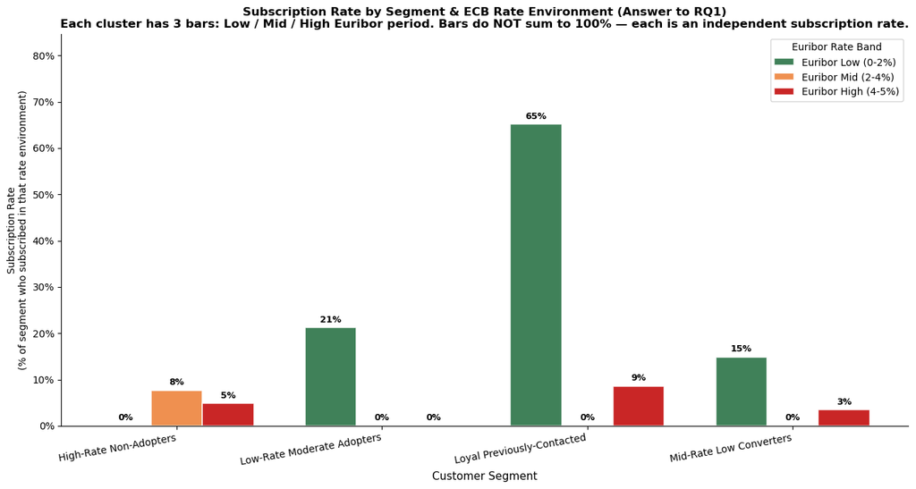

```python
bank_data_cluster['euribor_band'] = pd.cut(
    bank_data_cluster['euribor3m'], bins=[0, 2, 4, 5.1],
    labels=['Low (0-2%)', 'Mid (2-4%)', 'High (4-5%)'])

rate_data = bank_data_cluster.groupby(
    ['best_cluster', 'euribor_band'], observed=True)['target'].mean() * 100
rate_data = rate_data.reset_index()

# Guarantee every cluster has all 3 bands (fill 0 if no data in that band)
from itertools import product as iproduct
all_combos = pd.DataFrame(
    list(iproduct(sorted(bank_data_cluster['best_cluster'].unique()),
                  ['Low (0-2%)', 'Mid (2-4%)', 'High (4-5%)'])),
    columns=['best_cluster', 'euribor_band'])
all_combos['euribor_band'] = pd.Categorical(
    all_combos['euribor_band'],
    categories=['Low (0-2%)', 'Mid (2-4%)', 'High (4-5%)'], ordered=True)
rate_data = all_combos.merge(rate_data, on=['best_cluster','euribor_band'], how='left')
rate_data['target'] = rate_data['target'].fillna(0)

seg_labels = [segment_names.get(c, f"Cluster {c}")
              for c in sorted(bank_data_cluster['best_cluster'].unique())]
n_clusters = len(seg_labels)
bands      = ['Low (0-2%)', 'Mid (2-4%)', 'High (4-5%)']
b_cols     = ['#1E6B3C', '#ED7D31', '#C00000']
x          = np.arange(n_clusters)
width      = 0.25

fig, ax = plt.subplots(figsize=(13, 7))
for i, (band, color) in enumerate(zip(bands, b_cols)):
    vals = rate_data[rate_data['euribor_band'] == band]['target'].values
    bp   = ax.bar(x + i * width, vals, width,
                  label=f'Euribor {band}', color=color,
                  alpha=0.85, edgecolor='white', linewidth=1.2)
    for bar, val in zip(bp, vals):
        ax.text(bar.get_x() + bar.get_width()/2,
                val + 0.7, f'{val:.0f}%',
                ha='center', va='bottom', fontsize=9, fontweight='bold')

ax.set_xlabel("Customer Segment", fontsize=11)
ax.set_ylabel("Subscription Rate\n(% of segment who subscribed in that rate environment)", fontsize=10)
ax.set_title(
    "Subscription Rate by Segment & ECB Rate Environment (Answer to RQ1)\n"
    "Each cluster has 3 bars: Low / Mid / High Euribor period. "
    "Bars do NOT sum to 100% — each is an independent subscription rate.",
    fontweight='bold', fontsize=12)
ax.set_xticks(x + width)
ax.set_xticklabels(seg_labels, rotation=10, ha='right', fontsize=10)
ax.legend(title="Euribor Rate Band", fontsize=10, title_fontsize=10, loc='upper right')
ax.set_ylim(0, max(rate_data['target'].max() * 1.3, 25))
ax.yaxis.set_major_formatter(plt.FuncFormatter(lambda y, _: f'{y:.0f}%'))
plt.tight_layout()
plt.show()
```